# Simulating Harmonic Oscillator on a Lattice

physics

computational

path-integral

QM

Author

Zhaose

Published

January 18, 2026

# Concepts

For a harmonic oscillator, the lagrangian can be written as:
$$L = \frac{1}{2} m \dot{x}^2 - \frac{1}{2} m \omega^2 x^2$$
The two-point correlation function then, is
$$D_q(t_1, t_2) = \bra{q, T} \mathbf{x}(t_2) \mathbf{x}(t_1) \ket{q, 0}$$
If we transfer it into Shördinger picture, and insert sets of energy eigenstates, we have
$$\begin{align*}
& \bra{q, T} \mathbf{x}(t_2) \mathbf{x}(t_1) \ket{q, 0} \\
=& \bra{q} e^{-i \mathbf{H} (T - t_2)} \mathbf{x} e^{-i \mathbf{H} (t_2 - t_1)} \mathbf{x} e^{-i \mathbf{H} t_1} \ket{q} \\
=& \sum_{a,b,c,d} \bra{q} e^{-i \mathbf{H} (T - t_2)} \ket{a} \bra{a} \mathbf{x} \ket{b} \bra{b} e^{-i \mathbf{H}(t_2 - t_1)} \ket{c} \bra{c} \mathbf{x} \ket{d} \bra{d} e^{-i \mathbf{H} t_1} \ket{q} \\
=& \sum_{a,b,d} e^{-i H_a (T - t_2)} e^{-i H_d t_1} e^{-i H_b (t_2 - t_1)} \braket{d|q} \braket{q|a} \braket{a|\mathbf{x}|b} \braket{b|\mathbf{x}|d}
\end{align*}$$
It kinda looks like a mess. However, when we do simulation, we always impose the periodic boundary, so we should also do it here, then we have
$$\begin{align*}
=& \int dq \sum_{a,b,d} e^{-i H_a (T - t_2)} e^{-i H_d t_1} e^{-i H_b (t_2 - t_1)} \braket{d|q} \braket{q|a} \braket{a|\mathbf{x}|b} \braket{b|\mathbf{x}|d} \\
=& \sum_{a,b} e^{-i H_a (T - t_2 + t_1)} e^{-i H_b (t_2 - t_1)} \braket{a|\mathbf{x}|b} \braket{b|\mathbf{x}|d} \\
=& \sum_{a,b} e^{-i H_a (T - \Delta t)} e^{-i H_b \Delta t} \left|\braket{0|\mathbf{x}|1}\right|^2 \\
\end{align*}$$
Here we just be aware of that different energy eigenstates are orthogonal. To keeps things simple, if we only consider the leading term, which is $a,b = 0,1$, then we have
$$\begin{align*}
=& \int dq \bra{q, T} \mathbf{x}(t_2) \mathbf{x}(t_1) \ket{q, 0} \\
=& e^{-i H_0 T} \left|\braket{0|\mathbf{x}|1}\right|^2 (e^{-i \Delta H \Delta t} + e^{-i \Delta H (T - \Delta t)})
\end{align*}$$
Since the expectation of $\mathbf{x}$ is zero, some terms vanish. Note that the only non-constant here is $\Delta t$, which means
$$\int_{PB} Dx(t) \; x(t_1) x(t_2) exp\{i \int dt L \} \\
\propto e^{-i \Delta H \Delta t} + e^{-i \Delta H (T - \Delta t)}$$
Let $t \to -i \tau$, then we have
$$\int_{PB} Dx(\tau) \; x(\tau_1) x(\tau_2) exp\{- \int d\tau L_E \} \\
\propto e^{- \Delta H \Delta \tau} + e^{- \Delta H (\Tau - \Delta \tau)}
\tag{1}$$
Here
$$L_E = \frac{1}{2} m (\frac{dx}{d\tau})^2 + \frac{1}{2} m \omega^2 x^2
\tag{2}$$

# Simulation

If we can write some code to calculate Equation 1, then we can extract $\Delta H$ from it, by addressing its relation with $\Delta \tau$. Calculating such a path-integral may seem to be impossible, however, doing MC simulation, we first simply generate a lot of “paths”, make sure their weight is proportional to $exp\{-S_E\}$, then perform measurements on those paths, get the mean of all measurements, then we will have the approximation of Equation 1.

First, make our x dimension-free might be a good idea, although it’s not necessary here.
$$x = a \hat{x} \to \hat{\omega} = \omega \times a$$
Then define a struct to hold all essential variables, write the function to calculate the change of action after imposing a perturbation at $x(\tau)$

```julia
using Pkg
Pkg.add("Plots")
```

```julia
using Base.Threads
using Random
using Plots

struct World
  xs::Vector{Float64}
  lt::Int
  m::Float64
  ω::Float64
  pt::Float64
  rb::Vector{Any}
end

function gen_world(lt, m, ω, pt)
  red_t = filter(isodd, 1:lt)
  black_t = filter(iseven, 1:lt)
  return World(zeros(lt), lt, m, ω, pt, [red_t, black_t])
end

function get_action_diff(w, t, new_x)
  lt = w.lt
  old_x = w.xs[t]

  act_diff = 0.5 * w.m * w.ω^2 * (new_x^2 - old_x^2)
  for t_nb in mod1.((t-1, t+1), lt)
    act_diff += 0.5 * w.m * (new_x - old_x) * (new_x + old_x - 2 * w.xs[t_nb])
  end

  return act_diff
end
```

Here we separate points in to groups so we can update each group in parallel. Then is how to update the path.

```julia
function update_xs!(w, t)
  new_x = w.xs[t] + (rand() - 0.5) * 2 * w.pt

  act_diff = get_action_diff(w, t, new_x)
  if act_diff >= 0
    if exp(- act_diff) < rand()
      return false
    end
  end

  w.xs[t] = new_x
  return true
end

function sweep_w!(w; save_accept=false)
  accepts = Atomic{Int}(0)
  @threads for t in w.rb[1]
    acc = update_xs!(w, t)
    if save_accept
      atomic_add!(accepts, Int(acc))
    end
  end
  @threads for t in w.rb[2]
    acc = update_xs!(w, t)
    if save_accept
      atomic_add!(accepts, Int(acc))
    end
  end
  return accepts[] / w.lt
end
```

Here `exp(- act_diff) < rand()` make sure that the weight is properly generated. However, when running the simulation, we need to tune how much perturbtion is made each time, to keep the accept rate to about 1/2.

And to measure, we iterate all path points and take the mean, for each $\Delta t$

```julia
function measure_x2(w)
  x2_t = zeros(w.lt)
  for t_0 in 1:w.lt
    @threads for Δt in 0:(w.lt - 1)
      x2_t[Δt + 1] += w.xs[t_0] * w.xs[mod1(t_0 + Δt, w.lt)]
    end
  end
  x2_t = x2_t ./ w.lt
  return x2_t
end
```

Now the only thing left is to run the simulation and compare the result with our theoretical result, Equation 1.

```julia
w = gen_world(100, 1.0, 1.0 * 0.1, 2.0)

n_heat = 1000
println("HEATING...")
acc = 0
for i in 1:n_heat
  acc += sweep_w!(w; save_accept=true)
end
println("ACCEPTED RATE: $(acc / n_heat)")

n_measure = 1000

x2_t = zeros(w.lt)
println("MEASURING...")
for i in 1:n_measure
  for j in 1:1000
    sweep_w!(w)
  end
  x2_t .+= measure_x2(w)
end
x2_t ./= n_measure
push!(x2_t, x2_t[1])
```

Analyze the result, we have

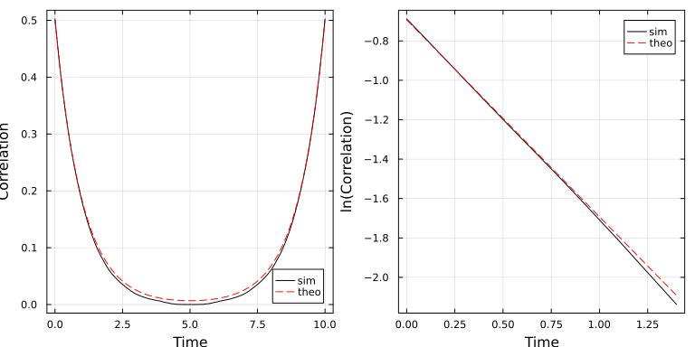

```julia
x2_normed = x2_t ./ sum(x2_t) .* 10.0

ts = (0:(w.lt)) ./ 10.0
function theo_fun(t)
  norm = 2.0 - exp(-10.0)
  return (exp(- 1.0 * t) + exp(- 1.0 * (10.0 - t))) / norm
end

p1 = plot(ts , x2_normed, label = "sim", color = :black, xlabel = "Time", ylabel="Correlation", framestyle = :box)
plot!(p1, ts, theo_fun, color = :red, label="theo", ls=:dash)

x2_samp = x2_normed[1:15]
t_samp  = ts[1:15]
p2 = plot(t_samp , log.(x2_samp), label = "sim", color = :black, xlabel = "Time", ylabel="ln(Correlation)", framestyle = :box)
plot!(p2, t_samp, (t) -> log(theo_fun(t)), color = :red, label="theo", ls=:dash)

plot(p1, p2, size=(800,400))
```

Note that only the slope in the second picture matters, which means it fits really well. So through this MC simulation, we can extract the difference between the first excited state and the groud state, which is $\hbar \omega$ in this case. More uses can be seen in Lattice-QCD, etc.